# HW2

claire

2018年9月21日

## 2.8

##### a.2391 people

##### b.People aged 65 or older

##### c.“People who attended a religious service once a week and prayed or studied the Bible once a day”&“less likely to have high blood pressure”

##### d.Sample data.Since they only observed a certain group of people rather than everyone who matches the standards.

## 2.20

##### the explanatory variable is “Whether a person smoking or not”,and it is a categorical variable; the response variable is “Likely to develop Alzheimer’s disease and other forms of dementia”, and it is categorical qantitative.

## 2.30

### a.

```r
(1700/2470)*100
```

```
## [1] 68.82591
```

##### About 69%

### b.

```r
1056/1700*100
```

```
## [1] 62.11765
```

##### About 62%

### c.

```r
300/657*100
```

```
## [1] 45.6621
```

##### About 46%

### d.

```r
41/113*100
```

```
## [1] 36.28319
```

##### About 36%

## 2.32

### a.

```r
library(ggplot2)
age<-c("<20","20~24","25~29","30~34","35 and over")
per<-c(20.9,30.6,24.7,15.7,8.1)
firkid<-data.frame(age,per)
firkid
```

```
##           age  per
## 1         <20 20.9
## 2       20~24 30.6
## 3       25~29 24.7
## 4       30~34 15.7
## 5 35 and over  8.1
```

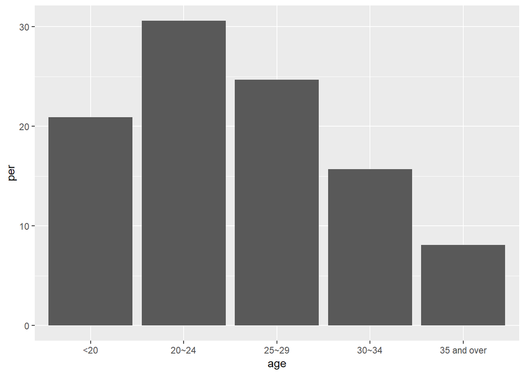

```r
ggplot(firkid,aes(x=age,y=per))+geom_col()
```

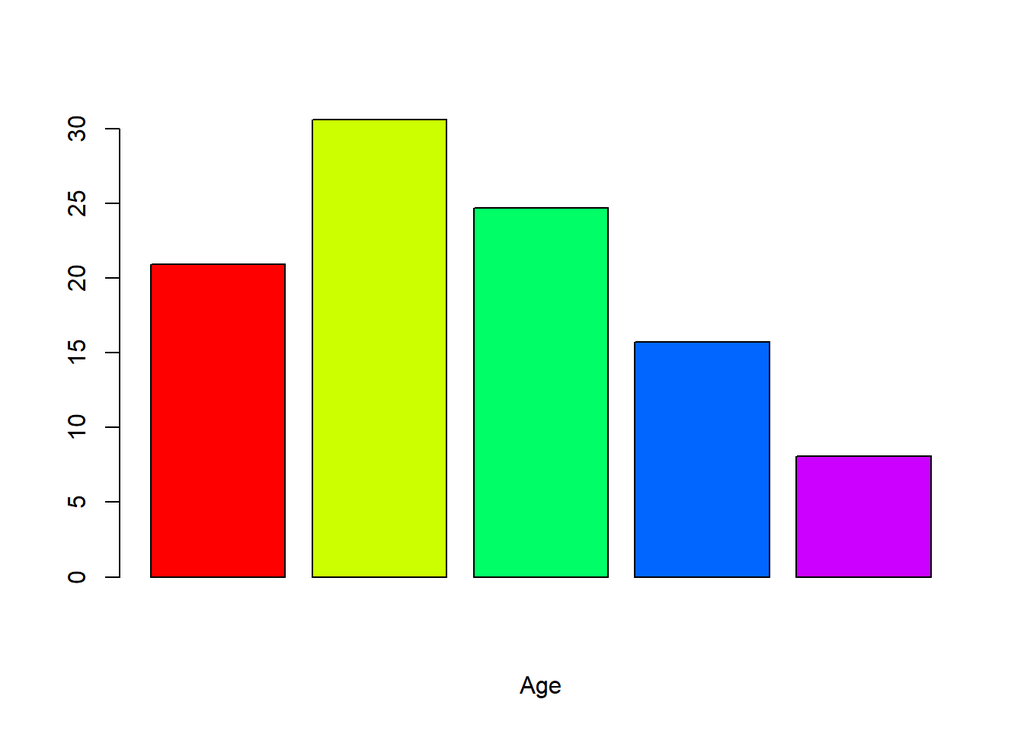

```r
barplot(per, col=rainbow(5),legend = rownames(age),xlab="Age")
```

### b.

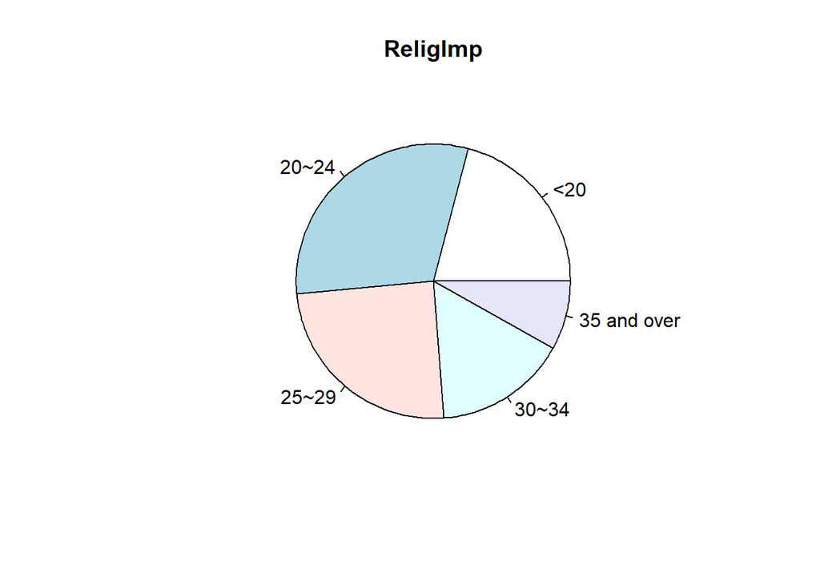

```r
lbls<-age
pie(per, labels = age,  main="ReligImp")
```

### c. ##### I think the pie chart is more informative because the data frame has a column of peercentage data, which is better to be shown by the pie chart.

## 2.46

### a.

```r
num<-c(220,20,50,450,300,30,20,50,200,35,25,50,250,100,0,100,20,13,200,2,125,150,90,60)
CD<-data.frame(num)
summary(CD)
```

```
##       num
##  Min.   :  0.00
##  1st Qu.: 23.75
##  Median : 55.00
##  Mean   :106.67
##  3rd Qu.:162.50
##  Max.   :450.00
```

```r
stem(CD$num,scale = 1)
```

```
##
##   The decimal point is 2 digit(s) to the right of the |
##
##   0 | 00122233455569
##   1 | 0035
##   2 | 0025
##   3 | 0
##   4 | 5
```

### b.

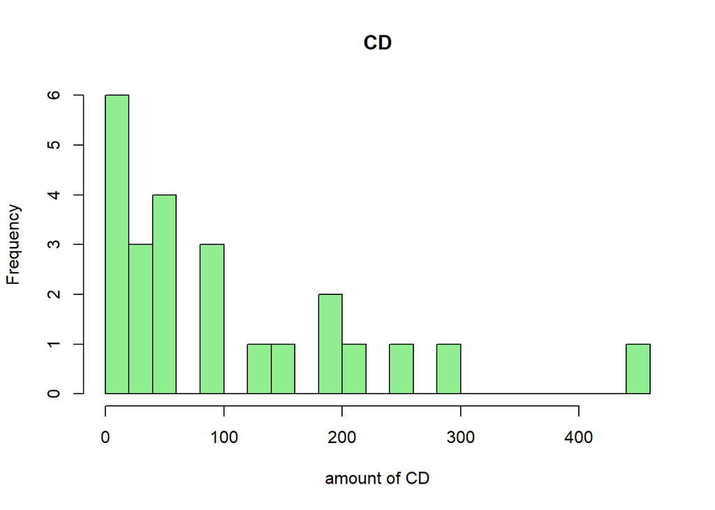

```r
hist(CD$num, breaks=20, col="light green",main="CD",xlab = "amount of CD")
```

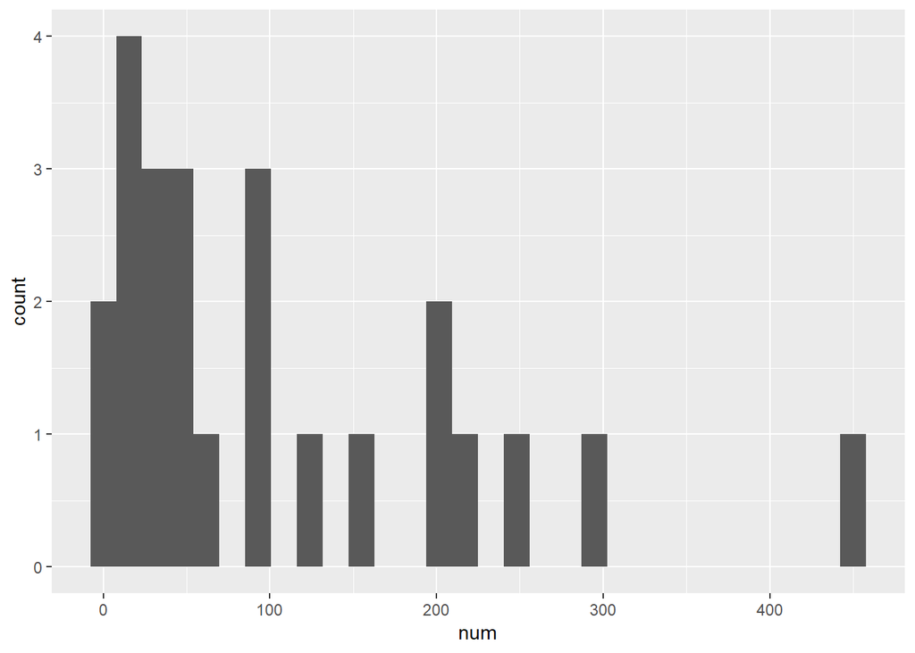

```r
ggplot(CD,aes(x=num))+geom_histogram()
```

### c.

##### Skew-right

## 2.52

### a.

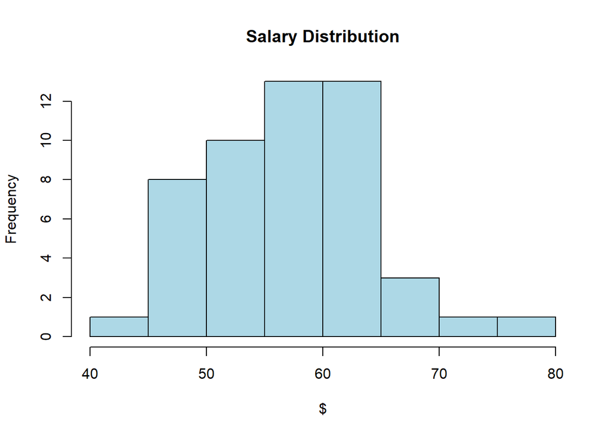

```r
ceodata08 <- c(42,47,48,49,49,50,50,50,50,51,51,51,52,54,54,55,55,55,55,56,57,57,57,57,57,58,58,59,59,60,60,60,61,61,62,62,62,62,62,63,63,64,64,64,64,67,67,69,74,78)
ceo<-data.frame(ceodata08)
hist(ceodata08, breaks=10, col="light blue", main="Salary Distribution", xlab="$")
```

### b.

```r
stem(ceodata08,scale = 1)
```

```
##
##   The decimal point is 1 digit(s) to the right of the |
##
##   4 | 2
##   4 | 7899
##   5 | 0000111244
##   5 | 55556777778899
##   6 | 0001122222334444
##   6 | 779
##   7 | 4
##   7 | 8
```

### c.

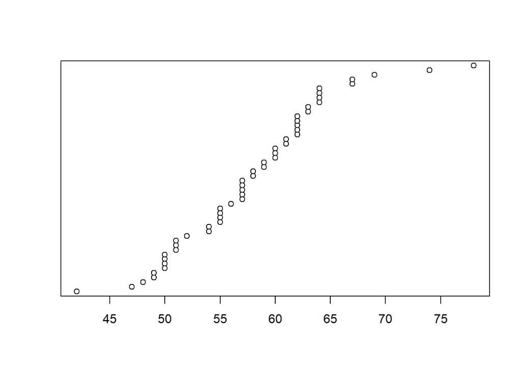

```r
dotchart(ceodata08, cex=1, lcolor = NULL)
```

### d.

##### Skew-right

### e.

##### Yes, it’s 78

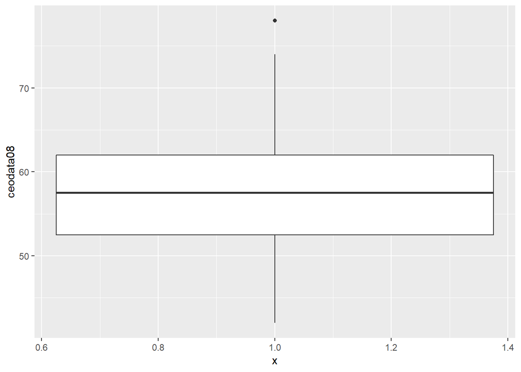

```r
ggplot(ceo,aes(x=1,y=ceodata08))+geom_boxplot()
```

### f.

##### I think outkiers would be more likely to occur in the salaries of heads of heads of companies since they tended to be strong enough yo give high salaries.

##### On the other hand, the ages of companies have weaker relationship between the outlier of salaries distribution.

## 2.66

```r
blood<-c(110,123,132,150,127,118,102,122)
summary(blood)
```

```
##    Min. 1st Qu.  Median    Mean 3rd Qu.    Max.
##   102.0   116.0   122.5   123.0   128.2   150.0
```

### a.

##### 122.5

### b.

##### lower quartile:116

##### upper quartile:128.2

### c.

```r
128.2-116
```

```
## [1] 12.2
```

##### interquartile range:12.2

### d.

```r
min<-quantile(blood,na.rm = TRUE)[2]-1.5*IQR(blood, na.rm = T)
min
```

```
##    25%
## 97.625
```

```r
max<-quantile(blood,na.rm = TRUE)[4]+1.5*IQR(blood, na.rm = T)
max
```

```
##     75%
## 146.625
```

##### there is a outlier in this data since 150>146.625, so 150 is a outlier.

### d.

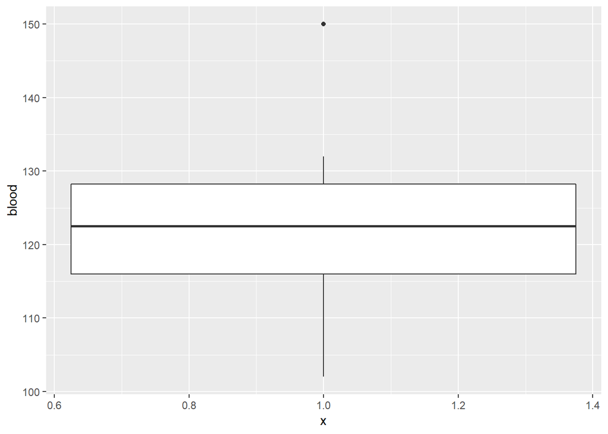

```r
bloodd<-data.frame(blood)
ggplot(bloodd,aes(x=1,y=blood))+geom_boxplot()
```

## 2.76

##### a.

```r
g1<-c(2,30,35,70,100,120,135,150,190,200)
summary(g1)
```

```
##    Min. 1st Qu.  Median    Mean 3rd Qu.    Max.
##    2.00   43.75  110.00  103.20  146.25  200.00
```

##### b.

```r
g2<-c(8,12,16,29,35,40,45,46,95)
summary(g2)
```

```
##    Min. 1st Qu.  Median    Mean 3rd Qu.    Max.
##    8.00   16.00   35.00   36.22   45.00   95.00
```

### c.

```r
r1<-200-2
r1
```

```
## [1] 198
```

```r
r2<-95-8
r2
```

```
## [1] 87
```

##### the range of Group1 is 198

##### the range of Group2 is 87

### d.

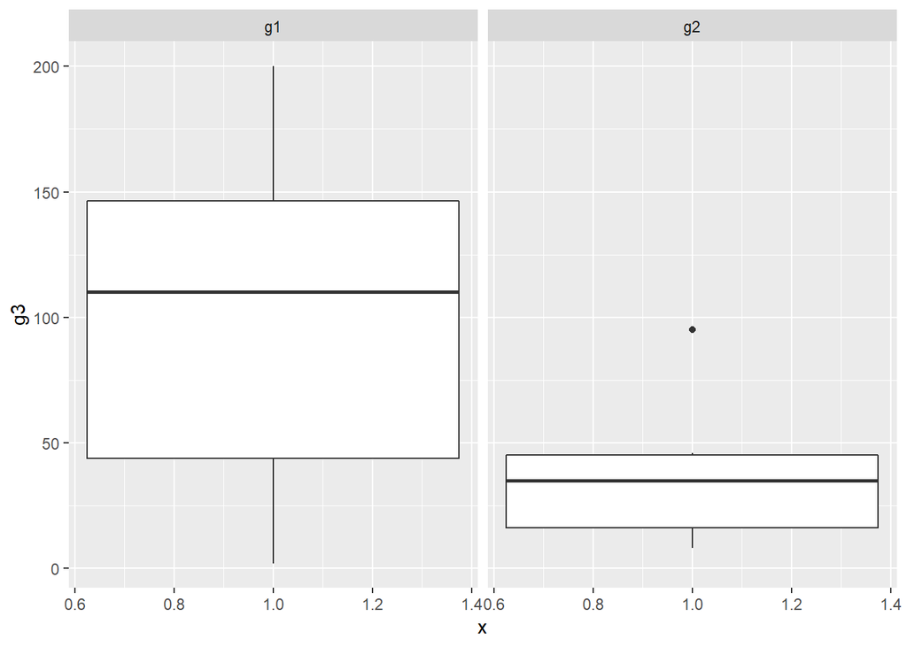

```r
g3<-c(2,30,35,70,100,120,135,150,190,200,8,12,16,29,35,40,45,46,95,NA)
g4<-c("g1","g1","g1","g1","g1","g1","g1","g1","g1","g1","g2","g2","g2","g2","g2","g2","g2","g2","g2","g2")
group<-data.frame(g3,g4)
ggplot(group,aes(x=1,y=g3))+geom_boxplot()+facet_grid(~g4)
```

##2.96 ##### I would be more satisfied if the standard deviation was 5. ##### if the standard deviation was 5, the z-Score is (80-70)/5=2, which meant that my score was higher than most of my classmates. ##### if the standard deviation was 15, the z-Score is (80-70)/15=0.67, which meant that my score was higher than many people yet not the most of people.

## 2.104

### To do 1

```r
smaller_head_circu<-56-2-2
smaller_head_circu
```

```
## [1] 52
```

### To do 2

```r
larger_head_circu<-56+2+2
larger_head_circu
```

```
## [1] 60
```

### To do 3

```r
larger_head_circu2<-56+2
larger_head_circu2
```

```
## [1] 58
```

## Overview the data

```r
stu_data<-read.csv("Student.csv")
head(stu_data)
```

```
##      Sex  GPA ReligImp MissClass   Seat PartyDays StudyHrs
## 1 Female 3.70   Fairly         1   Back         5        3
## 2   Male 3.20   Fairly         3  Front         3       30
## 3 Female 3.01   Fairly         0 Middle         8       16
## 4 Female 3.77      Not         0 Middle         0        4
## 5   Male 3.28      Not         0 Middle         8       12
## 6 Female 2.80   Fairly         0 Middle         2       20
```

```r
class(stu_data)
```

```
## [1] "data.frame"
```

## Observe the data

```r
counts <- table(stu_data$ReligImp)
counts
```

```
##
## Fairly    Not   Very
##    319    222    149
```

## pie chart

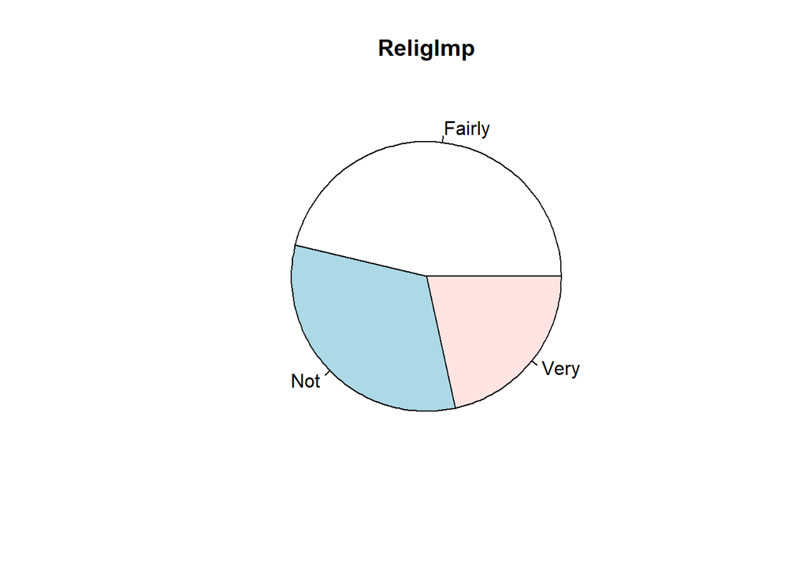

```r
lbls<-rownames(counts)
pie(counts, labels = lbls,  main="ReligImp")
```

## Histogram

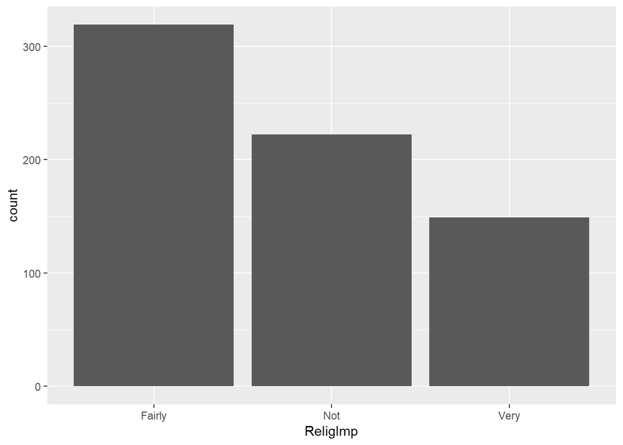

```r
library(ggplot2)
library(magrittr)
stu_data%>%ggplot(aes(x=ReligImp))+geom_bar()
```

# Find the outliers

```r
library(dplyr)
MyOutlierDetect<-function(vari,x){
  col<-read.csv("Student.csv")
  col<-select(stu_data,vari)
  col<-as.numeric(unlist(col))
  min<-quantile(col,na.rm = TRUE)[2]-1.5*IQR(col, na.rm = T)
  max<-quantile(col,na.rm = TRUE)[4]+1.5*IQR(col, na.rm = T)
  if (x<min|x>max){
    return("YES")
    }else{
    return("NO")
  }
  return(s)

}
MyOutlierDetect("PartyDays",10)
```

```
## [1] "NO"
```